# Video 1: PyMC3 Sampling

Now let's go out and use PyMC3 to look at an example about online advertisement. Online advertisement has ever expanding popularity because of rising internet penetration throughout the world. We can think of PyMC3 here as trying to combine data and all prior belief in a blackbox (i.e. we can't tell exactly the trajectory of each iteration) and we want to see the trajectory and infer knowledge from the distribution of posterior samples. In this example, our goal is really to find a distribution that best represents the cost that an individual online advertiser needs to spend on advertisement providers.

I'm going to make the problem a bit easier for teaching, so our research question is this: **Can we utilize the data about whether a user clicked into an advertisement or not and the advertisement provider to predict the cost that a company needs to offer online advertisement to reach 10,000 users?** We’ll see if we can find such a cost distribution.

```python
# Let's start with bringing in the pymc3 package
import pymc3 as pm
# and a couple of regular data science packages for our analysis.
import pandas as pd
import numpy as np
import seaborn as sns
import matplotlib.pyplot as plt
from scipy import stats
```

```
WARNING (theano.tensor.blas): Using NumPy C-API based implementation for BLAS functions.
```

```python
# We actually revisit the click-through rate example from week 3 in course 1. The data for this example
# is stored in our assets folder as online_ads.csv, and contains click-through results of couple hundreds
# of advertisement impressions.

# Now we load our dataframe from the csv file using the pd.read_csv function. This is just a handy way of
# loading csv datasets.

online_ads = pd.read_csv('assets/online_ads.csv')

# Now let's look at the header of this dataset.
online_ads.head()
```

|  | advertisement | provider | clicked | cost |
| --- | --- | --- | --- | --- |
| 0 | MongoDB | Google | 1 | 0.3 |
| 1 | MongoDB | Google | 0 | 0.3 |
| 2 | MongoDB | Google | 1 | 0.3 |
| 3 | MongoDB | Google | 0 | 0.3 |
| 4 | MongoDB | Google | 1 | 0.3 |

So our dataset records the name of the advertisement, the provider who launches the advertisement, whether a user visited the advertisement, and the cost of an advertisement impression. I recorded 1 in the clicked column if the user indeed clicked to the advertisement after impression, and 0 if not.

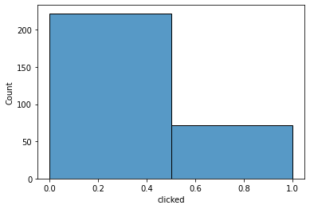

```python
# Let's do a little visual inspection of the proportion of successful advertisement clicks that we are interested in.
# We could simply draw a histogram using the sns.histplot function and customize it using the bins parameter
# and set it as 2.
sns.histplot(x = 'clicked', data = online_ads, bins=2)
# Cool! This gives us an impression that less than a half of users actually clicked on a specific link
# among all users who viewed a page, email, or advertisement.
```

```python
# Now let's subset the clicked column grouped by each provider, so create click_google
click_google = online_ads[online_ads['provider'] == 'Google']['clicked']
# and click_yahoo be pandas.Series as observed data.
click_yahoo = online_ads[online_ads['provider'] == 'Yahoo']['clicked']

# Cool! These series have all the records of whether or not a user clicked the advertisement link,
# so that's exactly the input of our model.
```